# Predicting Bicep Curl Quality via Random Forest

### Introduction

Sensor data was collected by the [Human Activity Recognition](http://groupware.les.inf.puc-rio.br/har) project of GroupWare during various exercises for the purpose of building models to automate the recognition of exercise quality. The data set under study here was for bicep curls. Two data sets, a training and a testing data set were provided. A predictive model was constructed using random forests. The final model achieved an in-model accuracy of 99.0%. When measured against a separate testing data set, the model gave a 99.2% accuracy. This is an exceptional result considering that prediction of movement quality is a novel area of research and that typical model accuracies in more mature fields are lower.

### Required Libraries

```r
library(caret)
library(rattle)
```

```r
library(ggplot2)
```

### Data Processing

Two data sets were provided, a [training data set](http://d396qusza40orc.cloudfront.net/predmachlearn/pmltraining.csv) and a [testing data set](http://d396qusza40orc.cloudfront.net/predmachlearn/pmltesting.csv).

```r
training <- read.csv("http://d396qusza40orc.cloudfront.net/predmachlearn/pml-training.csv",na.strings=c("NA","#DIV/0!"),stringsAsFactors=FALSE)
testing <- read.csv("http://d396qusza40orc.cloudfront.net/predmachlearn/pml-testing.csv",na.strings=c("NA","#DIV/0!"),stringsAsFactors=FALSE)
```

The training data set contained 19622 observations on 160 variables including an output quality classification of A, B, C, D, E.

Many of the variables in the data set contain mostly NAs.

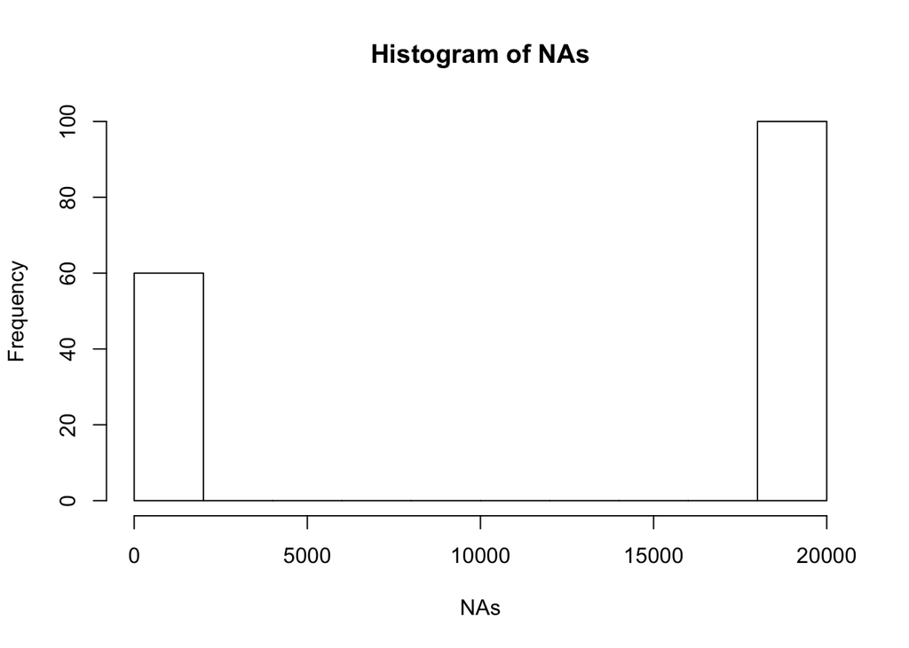

```r
NAs <- apply(training,2,function(v) sum(is.na(v)))
hist(NAs)
```

Though there might have been some information useful to model building, these were removed to speed construction.

```r
cleanPredictors <- function(data){

  clean <- data

  hasClass <- sum(names(data)=="classe")

  if(hasClass){clean[,-which(names(data) %in% c("classe"))]}

  # remove columns not used for prediction
  clean <- clean[,-which(names(data) %in% c("X","user_name","cvtd_timestamp","raw_timestamp_part_1","raw_timestamp_part_2","num_window","new_window"))]

  # Remove columns with lots of NAs
  good_columns <- apply(is.na(clean),2,sum)<10
  clean <- clean[,good_columns]

  # Convert remaining columns to numeric
  clean <- sapply(clean,as.numeric)

  clean <- data.frame(clean)

  # Add classe back to the frame
  if(hasClass){clean$classe <- factor(data$classe)}

  clean

}

cleanTraining <- cleanPredictors(training)
cleanTesting <- cleanPredictors(testing)
```

In addition, non-numeric variables, such as name, timestamp, etc. were removed from the data.

The final data set, prior to model building was reduced to 52 predictors and a single output variable.

### Model Construction

Initial model building focused on classification and regression trees given that this is a classification problem.

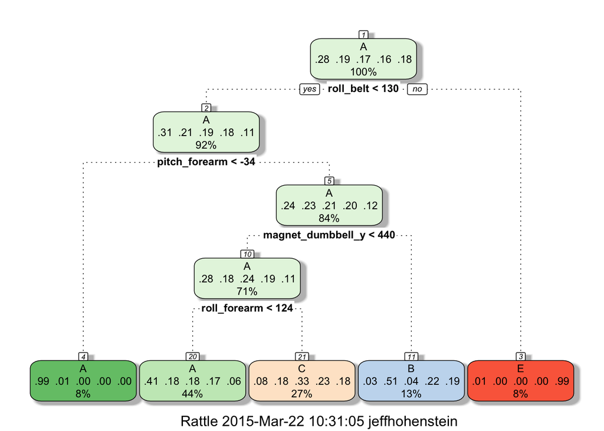

```r
cart <- train(classe ~ ., data=cleanTraining, method="rpart")
fancyRpartPlot(cart$finalModel)
```

Models built this way yielded relatively poor accuracy 0.5117601 but gave some insight into which predictors were most important in classifying the output.

After CART, Random Forests were selected as the final model building approach.

The training data set was divided into two partitions, a training partition and a validation partition with a 60/40 split. Random forests do internal “out-of-bag” estimation during model building but the validation partition gives an extra sense of confidence.

```r
set.seed(324565)
trainSet <- createDataPartition(cleanTraining$classe,p = .6,times=1,list=FALSE)
trainPart <- cleanTraining[trainSet,]
testPart <- cleanTraining[-trainSet,]
```

The training partition was 11776 observations. The validation partition was 7846 observations.

Model building was performed with the default 500 trees and using the default settings for number of predictors. Cross-validation was 5-fold in which the Random Forest algorithm internally partitions the data into 5 folds and uses 1 fold to assess the quality of the others.

```r
rfControl <- trainControl(
    method="cv",
    number=5,
    allowParallel=TRUE
  )

rfFit <- train(
  classe ~ .,
  data=trainPart,
  method="rf",
  importance=TRUE,
  proximity=TRUE,
  do.trace=TRUE,
  trControl = rfControl)
```

Load the precomputed model.

```r
load(file="rfFit.model")
```

### Model Quality

```r
rfFit$results
```

```
##   mtry  Accuracy     Kappa  AccuracySD     KappaSD
## 1    2 0.9878567 0.9846367 0.002092314 0.002648083
## 2   27 0.9899800 0.9873236 0.002642570 0.003343626
## 3   52 0.9830167 0.9785134 0.003612707 0.004573341
```

Following is the confusion matrix for the final model reported using the OOB cross-validation.

```
##      A    B    C    D    E class.error
## A 3341    5    1    0    1 0.002090800
## B   16 2258    5    0    0 0.009214568
## C    0   10 2034   10    0 0.009737098
## D    0    1   29 1899    1 0.016062176
## E    0    2    3    5 2155 0.004618938
```

Following is the confusion matrix for the validation partition.

```r
p <- predict(rfFit, newdata = testPart)
c <- confusionMatrix(p,testPart$classe)
c
```

```
## Confusion Matrix and Statistics
##
##           Reference
## Prediction    A    B    C    D    E
##          A 2229   18    0    0    1
##          B    1 1497   11    0    0
##          C    1    3 1352    8    4
##          D    0    0    5 1277    6
##          E    1    0    0    1 1431
##
## Overall Statistics
##
##                Accuracy : 0.9924
##                  95% CI : (0.9902, 0.9942)
##     No Information Rate : 0.2845
##     P-Value [Acc > NIR] : < 2.2e-16
##
##                   Kappa : 0.9903
##  Mcnemar's Test P-Value : NA
##
## Statistics by Class:
##
##                      Class: A Class: B Class: C Class: D Class: E
## Sensitivity            0.9987   0.9862   0.9883   0.9930   0.9924
## Specificity            0.9966   0.9981   0.9975   0.9983   0.9997
## Pos Pred Value         0.9915   0.9920   0.9883   0.9915   0.9986
## Neg Pred Value         0.9995   0.9967   0.9975   0.9986   0.9983
## Prevalence             0.2845   0.1935   0.1744   0.1639   0.1838
## Detection Rate         0.2841   0.1908   0.1723   0.1628   0.1824
## Detection Prevalence   0.2865   0.1923   0.1744   0.1642   0.1826
## Balanced Accuracy      0.9976   0.9921   0.9929   0.9957   0.9960
```

The estimated accuracy rate using the validation partition is 0.992.

### Variable Importance

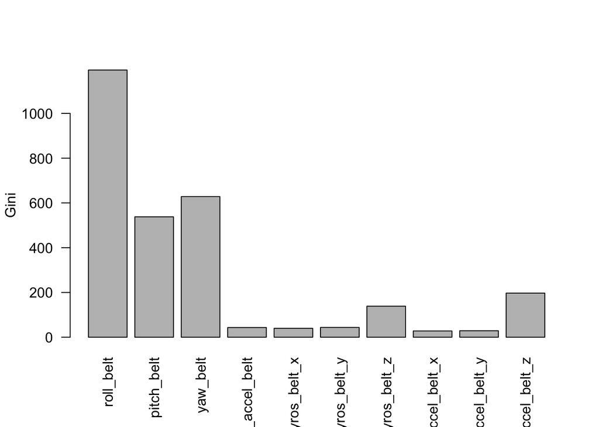

```r
par(las=2)
barplot(head(rfFit$finalModel$importance[,7],n=10),ylab="Gini")
```

### Conclusion

Random forests did an exceptional job at predicting exercise quality based on accelerometer-based human activity measurements yielding a suprisingly high accuracy of 0.992 given very modest up-front data manipulation. Training time was significant at around 2 hours for the final model but, once built, predictions were extremely fast. Supposing the model to be stable over time, this opens the possibility of portable, device-based assessments of exercise quality.